# Group1 Project

Zeynep Bal, Ayşegül Karakuş, Burcu Oral

03 01 2020

## INTRODUCTION

Data mining approaches are widely used in the prediction of the result of sports games. Since it is possible to win money by guessing which team will win or the total number of goals scored in football, people are looking for ways to predict the outcome acurately. In football predictions it is important to determine the features correctly so that the model results in accurate predictions. There are several publications that tries to predict the outcomes with many different features.

## RELATED LITERATURE

The most common methods used in football outcome predictions are Bayesian classifiers/regressors, Logistic Regression(LogR) , Support Vector Machines (SVM), Random Forest (RF), Gradient Boosting (GB) and K-nearest Neighbors.Besides them Deep learning and Artificial Neural Networks (ANN) are also employed. Since Poisson Regression, LogR,GB and RF are employed in this project, the literature about these methods are given below. Igiri et al. [1], used both artificial neural network (ANN) and logistic regression (LogR) techniques with 85% and 93% prediction accuracy respectively. With Bayesian approaches References [2] and [3] achieved around 92% accuracy.

For example [4] used SVM,LogR and RF for prediction with optimized parameters: for SVM, linear kernel and C= 0.005 with the prediction accuracy of 63.25; for LogR, C=0.001 with accuracy of 63.3; and for RF, 80 trees and 2 min. split with the accuracy of 62.26.

Ulmer and Fernandez achieved error rates of .48 with linear classifier; .50 with Random Forest and .50 with SVM [5].They used a small feature dataset.

It is also possible to have time dependent model like the work of Rue et al.[6], a Bayesian linear model is used to predict outcome taking into account the relative strength of attack and defense of each team.

In [7], the author used three major models: Generalized Boosted Models (GBM), K-nearest neighbor and Naive Bayes classification. Using GBM, they attained 60.22% accuracy on average, while the other models were not as accurate.

Regarding the poisson nature of football game results can result in good accuracy with smaller feature set [8].While the Poisson models predict the number of goals conceded and scored, the other statistical models restrict their prediction to match result. However, when goal driven models and match results driven model were compared in [9], it was found that LogR and Poisson approaches yield almost similar prediction performance.

Features that are used in predictions are divirsified; the playing conditions (home or away), fatigue levels, team selected by the manager and many other factors[10].There are team based and individual player based approaches for feature engineering. There can be ‘match-related’ and ‘external’ features. Match related features are actual events within the sport’s match. For example,meters gained, passes made can be regarded as match-related.External features can be recent form, travel, players available for the match, etc.[11].External features are known before the match but only an average of match related features for a certain number of past matches for these teams is known. Buursma [12] found that using an average across the past 20 matches for match-related features resulted in the best classification accuracy.

Leung et al. [13] analyze a set of teams that are the most similar to each of the competing teams, find the results of the games between the teams in each of the two sets, and use those game results to predict the outcome of the game between the original two teams. This approach analyzes past game results and a number of statistics about each of the teams from each of those games; such as passing attempts, rushing attempts, and turnovers for and against. Statistical data are stored in two data structures: (a) a list storing every game played over a given time and (b) a list storing all teams with their corresponding statistics from the season. So the approach parses the team lists and creates a map with every point representing a team. The distance between two points on the map is proportional to their similarity.

Reference [2] divided the data set into two;(a) non-physiological factors: weather, history of five previous matches, results against/for team, home game and players’ psychological state and (b) physiological factors: average age of the players, the number of injured main players, average match in a week, performance of main players, the performance of all players and average number of goals for all home and away matches.

Paper [14] used points for and against, win-loss record, home and away performance, performance in previous 4 games, ranking, location and player availability for premier league predictions and [15] used goals for, for shots,shots on goals, corner kicks, free kicks, ball possesion and fouls data for prediction in World Cup and reference [16] used goals for, goals against, result of previous match, top scorers, day since previous match as features in Dutch Eredivisie prediction.

In addition to all of these possible features there are some index calculation methods such as ELO rating and ICT index etc.. These indexes take into account basic knowledge, such as wins and losses, strength of schedule or point differential, but also knowledge of previous seasons [17]

## Gradiendt Boosting (GB)

Gradient Boosted Trees are used for training. In this approach, the number of trees are determined as 50, interaction dept as 1, shrinkage as 0.1 and number of observations in nodes are 10 with GBM. The probabilities of the home, draw and away conditions for the first 6 columns are as follow:

```
##   prob.away prob.draw prob.home real
## 1     0.272    0.0082     0.719 home
## 2     0.438    0.0195     0.542 away
## 3     0.249    0.0093     0.741 home
## 4     0.015    0.0106     0.974 home
## 5     0.588    0.0173     0.395 away
## 6     0.021    0.0138     0.965 home
```

## Random Forest(RF)

```
##    prob.away prob.draw prob.home real
## 1      0.400     0.014     0.586 home
## 3      0.120     0.030     0.850 away
## 9      0.132     0.030     0.838 home
## 17     0.014     0.030     0.956 home
## 22     0.530     0.014     0.456 away
## 27     0.022     0.048     0.930 home
```

## Logistic Regression (LogR)

Lasso logistic regression is also used to calculate the probabilites. Lasso provides good prediction accuracy due to the shrinkage of the coefficients. It reduces overfitting by eliminating irrelevant variables.

```
##    away                draw                home                real
## 1  "0.279907878703689" "0.146037355224793" "0.574054766071518" "home"
## 3  "0.347834659326338" "0.181477041442299" "0.470688299231362" "away"
## 9  "0.279907878703689" "0.146037355224793" "0.574054766071518" "home"
## 17 "0.127431049143257" "0.125413415235407" "0.747155535621336" "home"
## 22 "0.501516846017607" "0.138712136864105" "0.359771017118288" "away"
## 27 "0.170858248040721" "0.168153025122128" "0.660988726837151" "home"
```

## SELECTED APPROACH: POISSON DISTRUBUTION

The predicted probabilities for home/draw/away conditions are made with poisson distributions. As it is stated in the related literature section, poisson distribution can result in good accuracy with minimum number of variables. In our project,the only variables used for poission distributions are home id, away id, home number of goals and away number of goals. The number of goals scored by both home and away are poisson distributed.

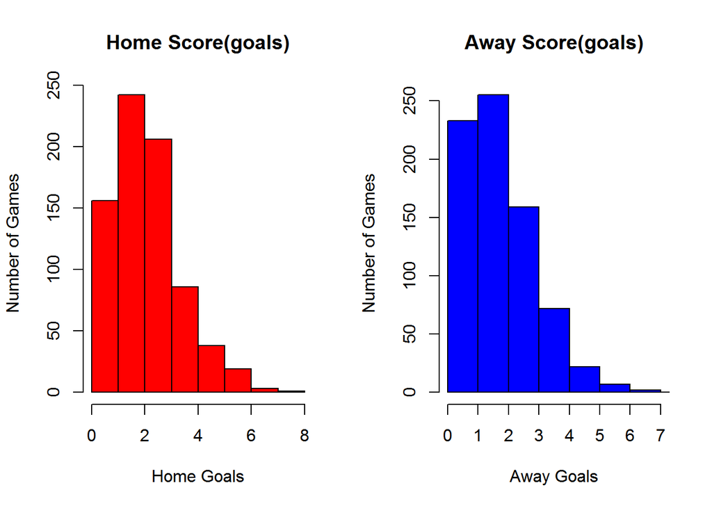

When the histograms are compared, it is seen that the number of goals scored by the home teams have higher frequencies for the higher number of the goals whereas away team have lower number of goals. However, in all the leagues there are so called the strong teams which scores higher goals no matter which one is hosting the game. Hence these teams have generally high probability, thus lower bet scores, to win.

```
##    match_hometeam_score match_awayteam_score         team_id
## 12            0.9024390            2.0975610 Manchester City
## 10            0.9772727            2.0000000       Liverpool
## 19            1.2187500            1.1875000          Wolves
## 20            1.3125000            1.2500000   Sheffield Utd
## 13            1.3265306            1.3877551  Manchester Utd
## 18            1.5333333            0.8000000         Norwich
## 6             1.5348837            1.4186047         Chelsea
## 14            1.5454545            1.5681818       Tottenham
## 1             1.5526316            1.6578947       Leicester
## 3             1.6000000            0.7750000        Brighton
## 8             1.6190476            1.1428571  Crystal Palace
## 9             1.6750000            1.0250000        West Ham
## 4             1.6818182            0.9318182     Southampton
## 7             1.6829268            1.1951220         Arsenal
## 16            1.7619048            0.8571429       Newcastle
## 15            1.8000000            0.9750000         Burnley
## 2             1.8974359            1.0256410         Everton
## 5             2.0000000            1.0952381     Bournemouth
## 11            2.0000000            0.8048780         Watford
## 17            2.0000000            1.3333333     Aston Villa
```

To sum up, team id of home and away teams and the number of goals scored by each team are taken as the features in this approach. For the probability calculations using Poisson regression, a matrix is obtained by simulation with using historical data. This matrix shows that the probabilities of two teams scoring a specific number of goals( selected max 10 goals). It calculates the odds of draw by summing diagonal, the odds of home team win by summing lower triangle and the odds of away team win by summing upper triangle.

```
##      home                draw                 away                 real
## [1,] "0.50583210740944 " "0.183177458153388 " "0.31087344939156  " "home"
## [2,] "0.336499554398154" "0.185838846795966 " "0.477563976484843 " "away"
## [3,] "0.398171290673742" "0.198673768993163 " "0.403121826592623 " "home"
## [4,] "0.664575525225266" "0.144910696247697 " "0.189552857530209 " "home"
## [5,] "0.238828128894492" "0.165466120639324 " "0.595369564767623 " "away"
## [6,] "0.526071420176964" "0.176414333072942 " "0.297316781854958 " "home"
```

## Discussion of the results

The results obtained with this four models are compared in this section with the table given below.

```
##   Summary  RPS Error
## 1     GBM 0.50  0.31
## 2      RF 0.48  0.40
## 3    LogR 0.37  0.21
## 4 Poisson 0.21  0.45
```

## CONCLUSIONS AND FEATURE WORKS

Poisson Regression is a very successful model in this case. The propabilty of match results are calculated with this model. Also the probabilites are calculated with other models which are GB, RF and LogR and the results are compared with rps performance metric and classification error. When the performance metrics were taken into consideration, it can be said that Poisson Regression was the best model because of it gets smaller value in terms of rps value. In addition, poisson regression is a good choice because the number of goals fit to Poisson distributions. As a conclusion, the best model is poisson regression for that prediction. Hence, the probability of home-away or draw of the teams were calculated based on poisson regression and related estimates were made on this model.

As for feature work, suitable features can be added to Poission distribution dataset. The features of our dataset are just numerical values but there are other factors that may effect the match result. The motivation of the team, the absence of a footboller, the tiredness and travelling amount may also be predictive. Otherwise, this model will give results in favor of strong team. Plus, the code can be altered to predict draw cases as well. In other word, the poisson distribution can be rewritten for multivariate analysis.

##CODE The code can be found at https://github.com/BU-IE-582/fall19-burcuoral/blob/master/Project-Group1.R.

### REFERENCES

[1] R.Igiri, C. Peace, A.Nwachukwu and E.Okechukwu, IOSR journal of Engineering, Vol.4, Issue 12,2014

[2] Baio G. and Blangiardo M., Bayesian Hierarchical Modelling for the Prediction of Football Results, Seminari del Dipartimento di Statistica,2009

[3] Owramipur F.,Eskandarian P., and Mozneb F.S., Football Result Prediction with Bayesian Network in Spanish League-Barcelona Team, International Journal of Computer Theory and Engineering, Vol. 5, No. 5, 2013

[4] Bosch, P., Predicting the winner of NFL-games using Machine and Deep Learning.

[5]Ulmer B.and Fernandez M., Predicting Soccer Match Results In The English Premier League, Stanford, 2014

[6]Rue H. And Salvesen O., Prediction And Retrospective Analysis Of Soccer Matches In A League. Journal Of The Royal Statistical Society: Series D, 2000

[7]Hijmans A., Dutch football prediction using machine learning classifiers

[8]Saraiva E. F., Suzuki A.K., Filho C. A. O., Louzada F., Predicting football scores via Poisson regression model: applications to the National Football League,Communications for Statistical Applications and Methods Vol. 23, No. 4, 297–319,2016

[9]Constantinaou C., Fenton N.E. and Neil M., A Bayesian network model for forecasting Association Football match outcomes, Working Papers, Queen Mary University, 2012

[10]Sathe S., Kasat D., Kulkarni N., Satao R.,Predictive Analysis Of Premier League Using Machine Learning, International Journal of Innovative Research in Computer and Communication Engineering Vol. 5, Issue 3, March 2017

[11] Bunker R.P.and Thabtah F., A machine learning framework for sport result prediction, Applied Computing and Informatics, Volume 15, Issue 1, 2019, Pages 27-33

[12] Buursma D., Predicting sports events from past results “Towards effective betting on football matches”, in: Conference Paper, presented at 14th Twente Student Conference on IT, Twente, Holland, 21 January 2011, 2001.

[13] Carson K. Leung, Kyle W. Joseph, Sports data mining: predicting results for the college football games, 18th International Conference on Knowledge-Based and Intelligent Information & Engineering Systems, Procedia Computer Science 35, 710 – 719,2014

[14]Mccabe, A. and Trevathan, J.,Artificial Intelligence in Sports Prediction. Fifth International Conference on Information Technology: New Generations, 2008

[15]Huang, K, and Chang, W., A neural network method for prediction of 2006 World Cup Football Ge. The 2010 International Joint Conference on Neural Networks, 2010

[16]Tax, N. and Joustra, Y.P., Predicting the Dutch football competition using public data: A machine learning approach, Trans. Knowl. Data Eng. Vol 10 , 2015

[17]N. Silver, “fivethirtyeight.com,” ESPN, September 2014. [Online]. Available: https://fivethirtyeight.com/features/introducing-nfl-elo-ratings/.

[18]Predicting football results with Poisson regression, March 2013 from : https://opisthokonta.net/?p=276